# Lab 4 - Logistic Regression

We will use credit card default data for this lab. The details can be found [here](http://archive.ics.uci.edu/ml/datasets/default+of+credit+card+clients). Think about what kind of factors could affect people who fail to pay their credit balance.

# Data Preparation and EDA

```r
credit.data <- read.csv("credit_default.csv")
dim(credit.data)
```

```
## [1] 12000    24
```

Take a look at the column names.

```r
t(t(names(credit.data)))
```

```
##       [,1]
##  [1,] "LIMIT_BAL"
##  [2,] "SEX"
##  [3,] "EDUCATION"
##  [4,] "MARRIAGE"
##  [5,] "AGE"
##  [6,] "PAY_0"
##  [7,] "PAY_2"
##  [8,] "PAY_3"
##  [9,] "PAY_4"
## [10,] "PAY_5"
## [11,] "PAY_6"
## [12,] "BILL_AMT1"
## [13,] "BILL_AMT2"
## [14,] "BILL_AMT3"
## [15,] "BILL_AMT4"
## [16,] "BILL_AMT5"
## [17,] "BILL_AMT6"
## [18,] "PAY_AMT1"
## [19,] "PAY_AMT2"
## [20,] "PAY_AMT3"
## [21,] "PAY_AMT4"
## [22,] "PAY_AMT5"
## [23,] "PAY_AMT6"
## [24,] "default.payment.next.month"
```

What proportion of people in this sample actually defaulted?

```r
mean(credit.data$default.payment.next.month)
```

```
## [1] 0.2193333
```

The name of the outcome variable is quite long. We might try renaming it using the rename() function.

```r
library(dplyr)
credit.data <- rename(credit.data, default = default.payment.next.month)
```

Take a look at variable types and summary statistics.

```r
str(credit.data)
```

```
## 'data.frame':    12000 obs. of  24 variables:
##  $ LIMIT_BAL: int  290000 20000 280000 280000 20000 50000 20000 30000 200000 110000 ...
##  $ SEX      : int  2 1 1 2 1 1 1 2 2 2 ...
##  $ EDUCATION: int  2 2 1 1 2 1 2 1 1 1 ...
##  $ MARRIAGE : int  2 2 2 2 2 2 2 2 1 2 ...
##  $ AGE      : int  26 51 29 47 24 26 23 25 38 29 ...
##  $ PAY_0    : int  0 -1 -2 0 0 -2 1 1 -2 0 ...
##  $ PAY_2    : int  0 -1 -2 0 0 -2 2 2 -2 0 ...
##  $ PAY_3    : int  0 -2 -2 0 0 -2 2 2 -2 2 ...
##  $ PAY_4    : int  0 -1 -2 0 0 -2 2 2 -2 0 ...
##  $ PAY_5    : int  -1 -1 -2 0 0 -2 2 0 -2 0 ...
##  $ PAY_6    : int  -1 -2 -2 0 0 -2 0 0 -2 0 ...
##  $ BILL_AMT1: int  18125 780 10660 269124 17924 2411 16332 29628 5625 107195 ...
##  $ BILL_AMT2: int  20807 0 5123 266163 18475 3059 18111 30453 12125 109443 ...
##  $ BILL_AMT3: int  99860 -1500 8467 215177 19539 2333 18325 30082 13300 106637 ...
##  $ BILL_AMT4: int  100000 780 2510 184270 19396 1800 18391 28933 3450 106665 ...
##  $ BILL_AMT5: int  3015 0 591 130954 11643 1620 14235 25255 13880 92417 ...
##  $ BILL_AMT6: int  23473 0 14994 92215 11578 0 18955 25344 5147 90730 ...
##  $ PAY_AMT1 : int  3000 0 5123 11268 1400 3068 2500 1600 12125 7845 ...
##  $ PAY_AMT2 : int  80000 0 8467 8196 1380 2440 1000 1000 13416 4000 ...
##  $ PAY_AMT3 : int  3000 2280 2510 6281 1181 1807 600 7 3450 4000 ...
##  $ PAY_AMT4 : int  3015 0 591 4403 1000 2204 0 880 13880 3500 ...
##  $ PAY_AMT5 : int  23473 0 14994 3532 500 0 5000 3028 5147 9500 ...
##  $ PAY_AMT6 : int  1148 0 5000 3510 500 0 1300 0 1050 9600 ...
##  $ default  : int  0 0 0 0 0 0 1 0 0 0 ...
```

```r
summary(credit.data)
```

```
##    LIMIT_BAL            SEX          EDUCATION        MARRIAGE
##  Min.   :  10000   Min.   :1.000   Min.   :1.000   Min.   :1.000
##  1st Qu.:  50000   1st Qu.:1.000   1st Qu.:1.000   1st Qu.:1.000
##  Median : 140000   Median :2.000   Median :2.000   Median :2.000
##  Mean   : 167501   Mean   :1.603   Mean   :1.844   Mean   :1.552
##  3rd Qu.: 240000   3rd Qu.:2.000   3rd Qu.:2.000   3rd Qu.:2.000
##  Max.   :1000000   Max.   :2.000   Max.   :4.000   Max.   :3.000
##       AGE           PAY_0              PAY_2            PAY_3
##  Min.   :21.0   Min.   :-2.00000   Min.   :-2.000   Min.   :-2.0000
##  1st Qu.:28.0   1st Qu.:-1.00000   1st Qu.:-1.000   1st Qu.:-1.0000
##  Median :34.0   Median : 0.00000   Median : 0.000   Median : 0.0000
##  Mean   :35.5   Mean   :-0.01575   Mean   :-0.128   Mean   :-0.1667
##  3rd Qu.:41.0   3rd Qu.: 0.00000   3rd Qu.: 0.000   3rd Qu.: 0.0000
##  Max.   :79.0   Max.   : 8.00000   Max.   : 7.000   Max.   : 7.0000
##      PAY_4             PAY_5             PAY_6           BILL_AMT1
##  Min.   :-2.0000   Min.   :-2.0000   Min.   :-2.0000   Min.   :-15308
##  1st Qu.:-1.0000   1st Qu.:-1.0000   1st Qu.:-1.0000   1st Qu.:  3690
##  Median : 0.0000   Median : 0.0000   Median : 0.0000   Median : 22658
##  Mean   :-0.2256   Mean   :-0.2678   Mean   :-0.2931   Mean   : 51392
##  3rd Qu.: 0.0000   3rd Qu.: 0.0000   3rd Qu.: 0.0000   3rd Qu.: 67207
##  Max.   : 7.0000   Max.   : 7.0000   Max.   : 8.0000   Max.   :964511
##    BILL_AMT2        BILL_AMT3         BILL_AMT4        BILL_AMT5
##  Min.   :-33350   Min.   :-157264   Min.   :-81334   Min.   :-81334
##  1st Qu.:  3156   1st Qu.:   2980   1st Qu.:  2411   1st Qu.:  1863
##  Median : 21652   Median :  20330   Median : 19078   Median : 18244
##  Mean   : 49246   Mean   :  47080   Mean   : 43102   Mean   : 40314
##  3rd Qu.: 63787   3rd Qu.:  59662   3rd Qu.: 53117   3rd Qu.: 49927
##  Max.   :983931   Max.   : 855086   Max.   :891586   Max.   :927171
##    BILL_AMT6          PAY_AMT1         PAY_AMT2            PAY_AMT3
##  Min.   :-339603   Min.   :     0   Min.   :      0.0   Min.   :     0
##  1st Qu.:   1309   1st Qu.:  1000   1st Qu.:    944.8   1st Qu.:   400
##  Median :  17130   Median :  2128   Median :   2013.0   Median :  1827
##  Mean   :  38821   Mean   :  5766   Mean   :   6250.1   Mean   :  5195
##  3rd Qu.:  48938   3rd Qu.:  5006   3rd Qu.:   5000.0   3rd Qu.:  4505
##  Max.   : 961664   Max.   :493358   Max.   :1227082.0   Max.   :896040
##     PAY_AMT4         PAY_AMT5         PAY_AMT6           default
##  Min.   :     0   Min.   :     0   Min.   :     0.0   Min.   :0.0000
##  1st Qu.:   300   1st Qu.:   300   1st Qu.:   142.8   1st Qu.:0.0000
##  Median :  1500   Median :  1518   Median :  1500.0   Median :0.0000
##  Mean   :  4878   Mean   :  4868   Mean   :  5432.7   Mean   :0.2193
##  3rd Qu.:  4078   3rd Qu.:  4121   3rd Qu.:  4061.8   3rd Qu.:0.0000
##  Max.   :432130   Max.   :426529   Max.   :528666.0   Max.   :1.0000
```

We see that all variables are **int**, but we know that *SEX*, *EDUCATION*, and *MARRIAGE* are categorical, so we’ll convert them to factors.

```r
credit.data$SEX <- as.factor(credit.data$SEX)
credit.data$EDUCATION <- as.factor(credit.data$EDUCATION)
credit.data$MARRIAGE <- as.factor(credit.data$MARRIAGE)
```

Usually, it is not a good choice to draw a scatter plot for categorical data. See the example below.

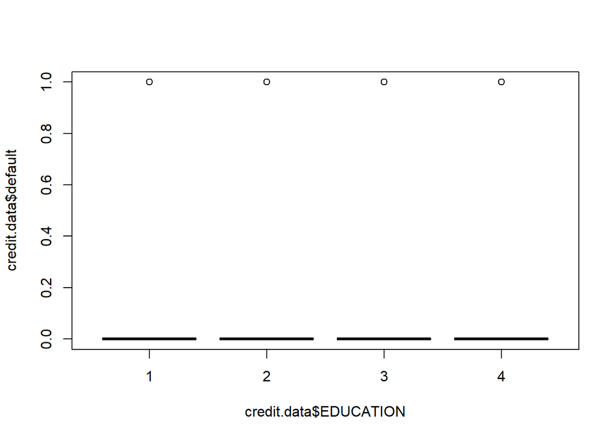

```r
plot(credit.data$default ~ credit.data$EDUCATION)
```

Can you get any useful information from the graph above?

## Two-Way Contingency Table and Chi-Square Test

A two-way contingency table is a very useful tool for exploring the relationship between categorical variables. It is essentially the simplest pivot table. (See example below.) Often, after creating a two-way contingency table, a chi-square test is used to determine whether two variables, X and Y, are independent. The null hypothesis is that X and Y are independent (e.g. there is no relationship between *EDUCATION* and *default*).

```r
table.edu <- table(credit.data$EDUCATION, credit.data$default)
table.edu
```

```
##
##        0    1
##   1 3399  829
##   2 4298 1298
##   3 1501  491
##   4  170   14
```

```r
chisq.test(table.edu)
```

```
##
##  Pearson's Chi-squared test
##
## data:  table.edu
## X-squared = 49.19, df = 3, p-value = 1.189e-10
```

We can see in the results above that the p-value is less than 0.05. Therefore, we would reject the null hypothesis and conclude that there is a relationship between *EDUCATION* and *default* (i.e. they are *not* independent).

*We’ll omit the remaining EDA here, but you shouldn’t whenever you’re performing data analysis.*

# Predictive Analysis of Credit Default Data Using Logistic Regression

Randomly split the data into training (80%) and validation (20%) datasets:

```r
set.seed(1)
index <- sample(nrow(credit.data), nrow(credit.data) * 0.8)
credit.train <- credit.data[index, ]
credit.valid <- credit.data[-index, ]
```

## Train a Logistic Regression with All Predictors

```r
credit.glm0 <- glm(default ~ ., family = "binomial", data = credit.train)
summary(credit.glm0)
```

```
##
## Call:
## glm(formula = default ~ ., family = "binomial", data = credit.train)
##
## Deviance Residuals:
##     Min       1Q   Median       3Q      Max
## -3.2059  -0.6947  -0.5353  -0.2755   3.5493
##
## Coefficients:
##               Estimate Std. Error z value Pr(>|z|)
## (Intercept) -9.536e-01  1.530e-01  -6.232  4.6e-10 ***
## LIMIT_BAL   -1.001e-06  2.883e-07  -3.473 0.000515 ***
## SEX2        -1.800e-01  5.465e-02  -3.293 0.000990 ***
## EDUCATION2  -1.293e-01  6.334e-02  -2.041 0.041228 *
## EDUCATION3  -2.408e-01  8.549e-02  -2.816 0.004858 **
## EDUCATION4  -1.235e+00  3.328e-01  -3.711 0.000206 ***
## MARRIAGE2   -1.908e-01  6.175e-02  -3.089 0.002006 **
## MARRIAGE3   -1.560e-02  2.379e-01  -0.066 0.947717
## AGE          7.198e-03  3.308e-03   2.176 0.029569 *
## PAY_0        5.967e-01  3.164e-02  18.859  < 2e-16 ***
## PAY_2        7.411e-02  3.585e-02   2.067 0.038712 *
## PAY_3        7.034e-02  3.976e-02   1.769 0.076898 .
## PAY_4        1.779e-02  4.504e-02   0.395 0.692765
## PAY_5        9.897e-02  4.787e-02   2.067 0.038690 *
## PAY_6       -3.023e-02  4.023e-02  -0.751 0.452457
## BILL_AMT1   -5.444e-06  1.953e-06  -2.787 0.005323 **
## BILL_AMT2    3.309e-06  2.560e-06   1.292 0.196208
## BILL_AMT3    8.297e-07  2.378e-06   0.349 0.727180
## BILL_AMT4   -3.315e-06  2.596e-06  -1.277 0.201727
## BILL_AMT5    2.795e-06  2.878e-06   0.971 0.331371
## BILL_AMT6    7.943e-07  2.225e-06   0.357 0.721044
## PAY_AMT1    -7.979e-06  3.227e-06  -2.472 0.013421 *
## PAY_AMT2    -6.765e-06  3.297e-06  -2.052 0.040154 *
## PAY_AMT3    -4.081e-06  3.507e-06  -1.164 0.244582
## PAY_AMT4    -7.398e-06  3.427e-06  -2.159 0.030869 *
## PAY_AMT5    -3.595e-06  3.230e-06  -1.113 0.265780
## PAY_AMT6    -1.686e-06  2.130e-06  -0.792 0.428556
## ---
## Signif. codes:  0 '***' 0.001 '**' 0.01 '*' 0.05 '.' 0.1 ' ' 1
##
## (Dispersion parameter for binomial family taken to be 1)
##
##     Null deviance: 10093.8  on 9599  degrees of freedom
## Residual deviance:  8791.8  on 9573  degrees of freedom
## AIC: 8845.8
##
## Number of Fisher Scoring iterations: 6
```

glm() is the main function used to build logistic regression models. The *family* argument specifies the distribution of your response variable.

### Metrics for Model Fitting

You can extract some metrics for the fit of your model - for example, residual deviance (equivalent to SSE in a linear regression model), AIC, and BIC. Unlike linear regression models, there is no *R*<sup>2</sup>.

```r
credit.glm0$deviance
```

```
## [1] 8791.782
```

```r
AIC(credit.glm0)
```

```
## [1] 8845.782
```

```r
BIC(credit.glm0)
```

```
## [1] 9039.359
```

## Prediction

Similar to linear regression, we use the predict() function for prediction.

### In-Sample Prediction (less important)

```r
library(forecast)
pred.glm0.train <- predict(credit.glm0, type = "response")
```

**IMPORTANT!!!** You must specify type = “response” in order to get the probability outcome, which is what we want here. Otherwise, what it produces is the linear predictor term (the logit term) $\beta_{0} + \beta_{1}x_{1} + \beta_{2}x_{2} + ...$ Recall from the lecture how this linear function is related to probability.

#### ROC Curve

```r
library(pROC)
r <- roc(credit.train$default, pred.glm0.train)
```

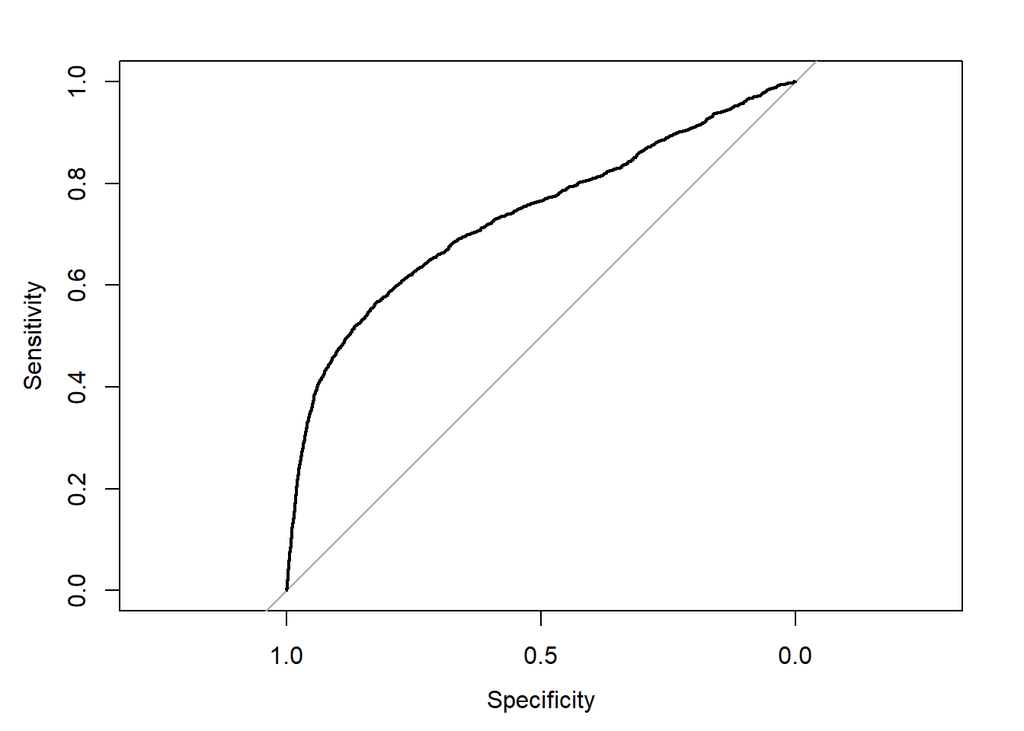

```r
plot.roc(r)
```

```r
auc(r)
```

```
## Area under the curve: 0.7346
```

### Out-of-Sample Prediction (more important)

```r
pred.glm0.valid <- predict(credit.glm0, newdata = credit.valid, type = "response")
```

For out-of-sample prediction (predicting outcomes on the validation data, for example), you have to specify newdata = “validation sample name”.

#### ROC Curve

```r
r <- roc(credit.valid$default, pred.glm0.valid)
```

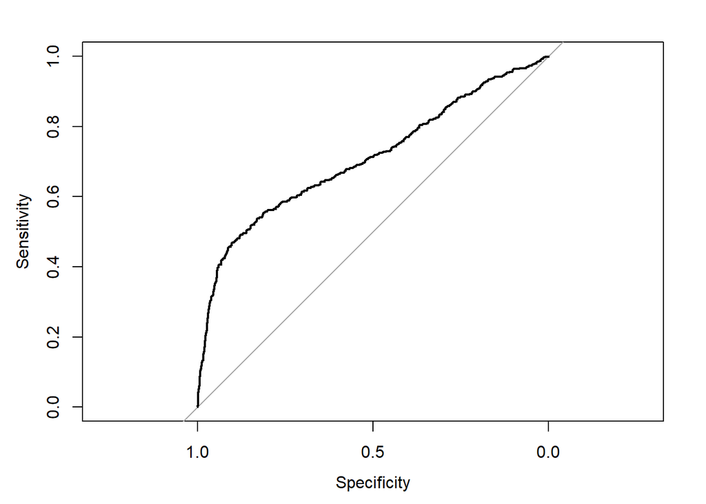

```r
plot.roc(r)
```

```r
auc(r)
```

```
## Area under the curve: 0.7079
```

#### Lift Charts

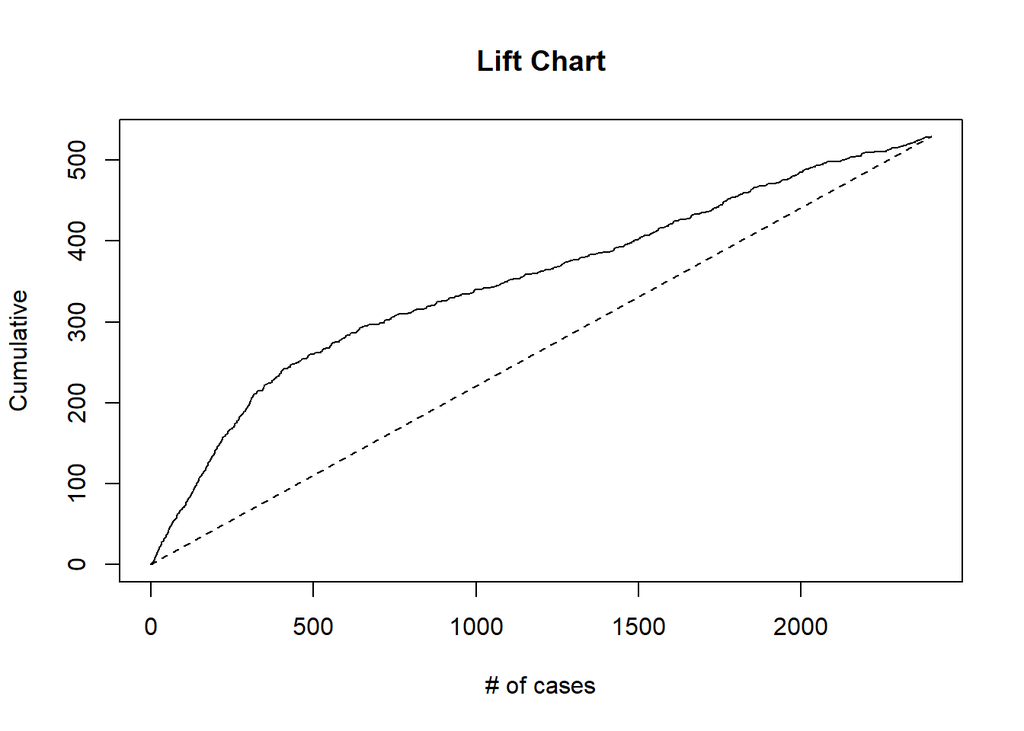

```r
# creating lift charts and decile lift charts
library(gains)
gain <- gains(credit.valid$default, pred.glm0.valid, groups = length(pred.glm0.valid))

# plot lift chart
plot(c(0, gain$cume.pct.of.total * sum(credit.valid$default)) ~ c(0, gain$cume.obs),
     xlab = "# of cases", ylab = "Cumulative", main = "Lift Chart", type = "l")
lines(c(0, sum(credit.valid$default)) ~ c(0, nrow(credit.valid)), lty = 2)
```

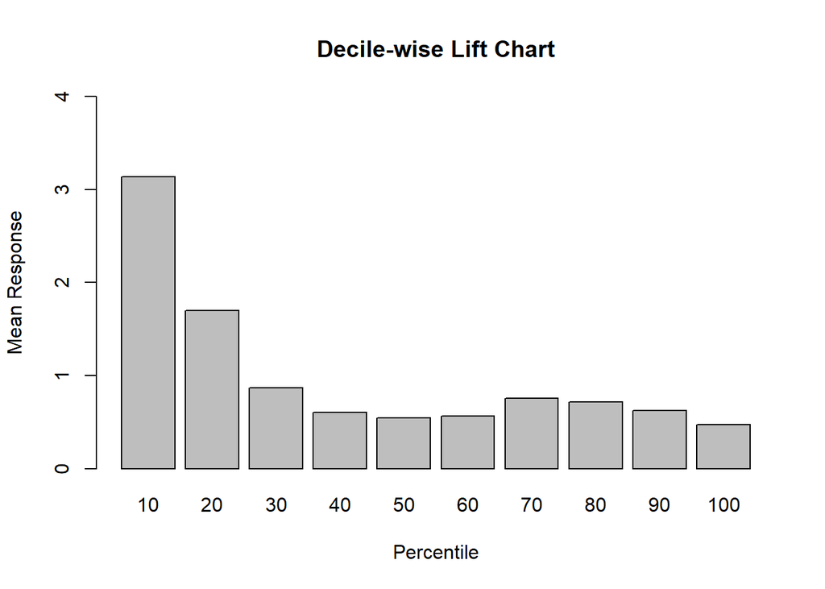

```r
# compute deciles and plot decile-wise lift chart
gain <- gains(credit.valid$default, pred.glm0.valid)
heights <- gain$mean.resp / mean(credit.valid$default)
dec.lift <- barplot(heights, names.arg = gain$depth, ylim = c(0, 4),
                    xlab = "Percentile", ylab = "Mean Response", main = "Decile-wise Lift Chart")
```

What do these lift charts tell you about the model’s classification performance on the validation data?

## Binary Classification

As discussed in the lecture, in data mining applications we are more interested in the classification results than the explanatory model. But we should define a cutoff probability first.

Recall that the default cutoff probability is 0.5.

```r
library(caret)
confusionMatrix(as.factor(ifelse(pred.glm0.train >= 0.5, "1", "0")), as.factor(credit.train$default),
                positive = "1")
```

```
## Confusion Matrix and Statistics
##
##           Reference
## Prediction    0    1
##          0 7280 1554
##          1  217  549
##
##                Accuracy : 0.8155
##                  95% CI : (0.8076, 0.8232)
##     No Information Rate : 0.7809
##     P-Value [Acc > NIR] : < 2.2e-16
##
##                   Kappa : 0.3009
##
##  Mcnemar's Test P-Value : < 2.2e-16
##
##             Sensitivity : 0.26106
##             Specificity : 0.97106
##          Pos Pred Value : 0.71671
##          Neg Pred Value : 0.82409
##              Prevalence : 0.21906
##          Detection Rate : 0.05719
##    Detection Prevalence : 0.07979
##       Balanced Accuracy : 0.61606
##
##        'Positive' Class : 1
##
```

Note that with a cutoff of 0.5, only about 26% of defaulters are correctly identified.

### Naive Choice of Cutoff Probability

Another option for the cutoff value is proportion of successes from the training data. This is roughly reasonable because the sample proportion is an estimate of the mean probability of $Y = 1$.

```r
pcut1 <- mean(credit.train$default)
pcut1
```

```
## [1] 0.2190625
```

Based on this cutoff probability, we can obtain the binary prediction (predicted classification) and the confusion matrix.

```r
# get binary prediction
class.glm0.train <- (pred.glm0.train > pcut1) * 1
# get confusion matrix
confusionMatrix(as.factor(class.glm0.train), as.factor(credit.train$default),
                positive = "1")
```

```
## Confusion Matrix and Statistics
##
##           Reference
## Prediction    0    1
##          0 5234  712
##          1 2263 1391
##
##                Accuracy : 0.6901
##                  95% CI : (0.6807, 0.6993)
##     No Information Rate : 0.7809
##     P-Value [Acc > NIR] : 1
##
##                   Kappa : 0.2842
##
##  Mcnemar's Test P-Value : <2e-16
##
##             Sensitivity : 0.6614
##             Specificity : 0.6981
##          Pos Pred Value : 0.3807
##          Neg Pred Value : 0.8803
##              Prevalence : 0.2191
##          Detection Rate : 0.1449
##    Detection Prevalence : 0.3806
##       Balanced Accuracy : 0.6798
##
##        'Positive' Class : 1
##
```

### Determine Optimal Cutoff Probability Using Grid Search Method

Recall from lecture that different cutoff values result in different confusion matrices (though not different models) and thus different misclassification rates and costs. You can search all possible cutoffs to find the one that provides minimum cost. The first step is to define a cost function as a function of the cutoff. Suppose it is 5 times more costly to misclassify a 1 as a 0 than to misclassify a 0 as a 1.

```r
# define a cost function with input "obs" being the observed response,
# "pred.p" being predicted probability, and "pcut" being the threshold
costfunc <- function(obs, pred.p, pcut){
    weight1 <- 5 # define the weight for "true=1 but pred=0" (false negative)
    weight0 <- 1 # define the weight for "true=0 but pred=1" (false positive)
    c1 <- (obs == 1) & (pred.p < pcut) # count for "true=1 but pred=0" (false negative)
    c0 <- (obs == 0) & (pred.p >= pcut) # count for "true=0 but pred=1" (false positive)
    cost <- mean(weight1 * c1 + weight0 * c0) # misclassification with weight
    return(cost) # you have to return a value when you write R functions
} # end of the function
```

Next, define a sequence of probability cutoffs. You will search for the optimal cutoff from this sequence.

```r
# define a sequence from 0.01 to 1 by 0.01
p.seq <- seq(from = 0.01, to = 1, by = 0.01)
```

Then, you need to calculate the cost (as defined above) for each probability cutoff in the sequence p.seq.

```r
# write a loop for all potential cutoff values to see which provides the smallest cost
# first, you need to define a 0 vector in order to save the values of cost from all cutoffs
cost <- rep(0, length(p.seq))
for (i in 1:length(p.seq)) {
    cost[i] <- costfunc(obs = credit.train$default, pred.p = pred.glm0.train, pcut = p.seq[i])
} # end of the loop
```

Last, draw a plot of cost vs. p.seq and find the pcut that gives you the minimum cost

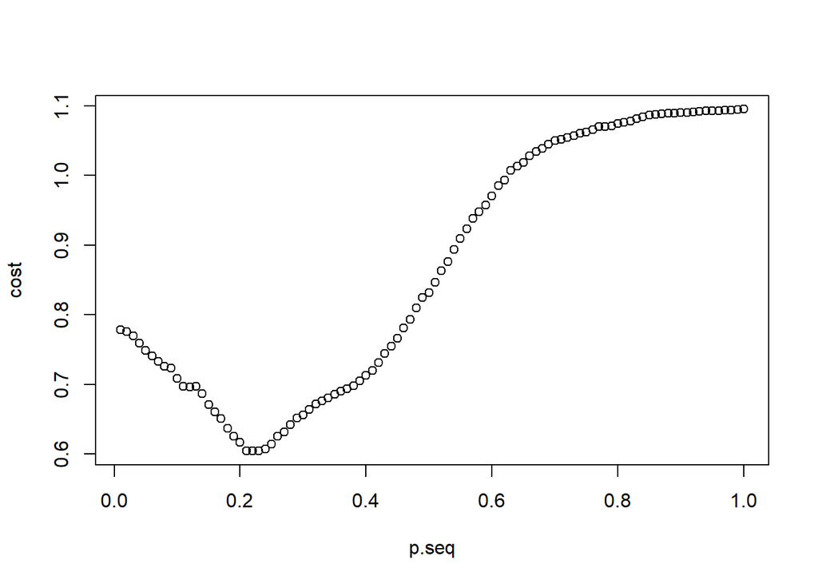

```r
# draw a plot with the x-axis being all pcut and y-axis being associated cost
plot(cost ~ p.seq)
```

Find the optimal pcut.

```r
optimal.pcut.glm0 <- p.seq[which(cost == min(cost))]
optimal.pcut.glm0
```

```
## [1] 0.21
```

#### Use the Optimal Cutoff Probability

Now, let’s create the confusion matrix and look at the misclassification rate, cost, and other metrics based on the optimal cutoff.

```r
confusionMatrix(as.factor(ifelse(pred.glm0.train >= optimal.pcut.glm0, "1", "0")), as.factor(credit.train$default),
                positive = "1")
```

```
## Confusion Matrix and Statistics
##
##           Reference
## Prediction    0    1
##          0 4947  650
##          1 2550 1453
##
##                Accuracy : 0.6667
##                  95% CI : (0.6571, 0.6761)
##     No Information Rate : 0.7809
##     P-Value [Acc > NIR] : 1
##
##                   Kappa : 0.2647
##
##  Mcnemar's Test P-Value : <2e-16
##
##             Sensitivity : 0.6909
##             Specificity : 0.6599
##          Pos Pred Value : 0.3630
##          Neg Pred Value : 0.8839
##              Prevalence : 0.2191
##          Detection Rate : 0.1514
##    Detection Prevalence : 0.4170
##       Balanced Accuracy : 0.6754
##
##        'Positive' Class : 1
##
```

```r
cost <- costfunc(obs = credit.train$default, pred.p = pred.glm0.train, pcut = optimal.pcut.glm0)
cost
```

```
## [1] 0.6041667
```

### Exercise

- Change the weights to different values and observe how the optimal cutoff changes.
- Obtain the confusion matrix and calculate the asymmetric cost based on the optimal cutoff.
- Find the optimal cutoff probability if the costs are symmetric.
- Calculate the misclassification rate and cost. What do you find?
- (Optional) Try rewriting the cost function to make the weights (or the ratio of two weights) input parameters.

### Out-of-Sample Classification

Everything you have done so far in this lab has been for the training sample. Now take a look at the validation sample. Keep in mind that the validation sample is used for evaluating your model’s prediction accuracy. No need to choose the cutoff probability at this stage.

#### Exercise

- Find the misclassification rate, sensitivy, specificity, and precision of your model on the validation data using the optimal cutoff you got from the training sample with 5:1 weights.
- Calculate the asymmetric cost on the validation sample based on the optimal cutoff you got from the training sasmple with the 5:1 weights.
- Calculate the above statistics on the validation sample based on the cutoff you got from the training sample with symmetric 1:1 weights.

## Variable Selection

### Variable Selection with Logistic Regression

We can use the same variable selection algorithms (i.e. forward, backward, and stepwise) for logistic regression that we used for linear regression models. **Caution: this may take a long time since the sample size is not small.**

```r
credit.glm.null <- glm(default ~ 1, data = credit.train, family = "binomial")
credit.glm.fwd <- step(credit.glm.null, scope = list(credit.glm.null, upper = credit.glm0), direction = "forward")
summary(credit.glm.fwd)
credit.glm.fwd$deviance
AIC(credit.glm.fwd)
BIC(credit.glm.fwd)
```

#### Exercise

- Try backward elimination and stepwise regression to see if they deliver the same best model.
- Get the ROC curve and AUC for both the training and validation samples.
- Using the training sample, find the optimal cutoff using the grid search method with asymmetric cost (5:1).
- Create the confusion matrix and find the misclassification rate, sensitivity, specificity, and cost for the validation sample. How do these compare to the results from the full model?

# Summary

Things to remember:

- How to use glm() to perform logistic regression
- How to get the ROC curve and AUC based on predicted probability
- How to find the optimal cutoff
- How to perform binary classification and find misclassification rate, sensitivity, specificity, and precision
- How to perform variable selection algorithms for logistic regression